# Feature Engineering Model Selection and Tuning Project

#### Developed by: Olabode James

## Preliminaries

### Project Context:

To predict the concrete strength using the data available in file concrete_data.xls. Apply feature engineering and model tuning to obtain 80% to 95% of R2score.

### Import Libraries

```python
import numpy as np # linear algebra
import pandas as pd


#Visualization Components
import seaborn as sns
import matplotlib.pyplot as plt # matplotlib.pyplot plots data
sns.set(color_codes=True) # adds a nice background to the graphs
# In order to enable plotting graphs in Jupyter notebook
%matplotlib inline

#Cross validation and data split
from sklearn.model_selection import train_test_split
from sklearn.model_selection import KFold
from sklearn.model_selection import cross_val_score, cross_val_predict

#ML Models For use
from sklearn.linear_model import LinearRegression
from sklearn.linear_model import Ridge
from sklearn.linear_model import Lasso
from sklearn.tree import DecisionTreeRegressor
from sklearn.svm import SVR
from sklearn.ensemble import RandomForestRegressor
from sklearn.ensemble import GradientBoostingRegressor

#Features Selection
from mlxtend.feature_selection import SequentialFeatureSelector as sfs
from mlxtend.plotting import plot_sequential_feature_selection as plot_sfs

#Regression metrics
from sklearn import metrics
from sklearn.metrics import mean_squared_error, r2_score, mean_absolute_error, explained_variance_score
from sklearn import linear_model

#Pipeline
from sklearn.pipeline import make_pipeline


#Hyperparameter Tuning
from sklearn.model_selection import GridSearchCV
from sklearn.model_selection import RandomizedSearchCV

#Standard maths
import math

#Features preProcessing
from scipy.stats import zscore
from sklearn.preprocessing import PolynomialFeatures
from sklearn.preprocessing import RobustScaler
from sklearn.preprocessing import StandardScaler

#Handling Statistical Components
import statsmodels.api as sm

#Need to handle warnings
import warnings
warnings.filterwarnings('ignore')
```

```python
#pip install mlxtend
```

#### Load and Preview Data

```python
concData = pd.read_csv('concrete.csv')
```

```python
concData.head(10)
```

|  | cement | slag | ash | water | superplastic | coarseagg | fineagg | age | strength |
| --- | --- | --- | --- | --- | --- | --- | --- | --- | --- |
| 0 | 141.3 | 212.0 | 0.0 | 203.5 | 0.0 | 971.8 | 748.5 | 28 | 29.89 |
| 1 | 168.9 | 42.2 | 124.3 | 158.3 | 10.8 | 1080.8 | 796.2 | 14 | 23.51 |
| 2 | 250.0 | 0.0 | 95.7 | 187.4 | 5.5 | 956.9 | 861.2 | 28 | 29.22 |
| 3 | 266.0 | 114.0 | 0.0 | 228.0 | 0.0 | 932.0 | 670.0 | 28 | 45.85 |
| 4 | 154.8 | 183.4 | 0.0 | 193.3 | 9.1 | 1047.4 | 696.7 | 28 | 18.29 |
| 5 | 255.0 | 0.0 | 0.0 | 192.0 | 0.0 | 889.8 | 945.0 | 90 | 21.86 |
| 6 | 166.8 | 250.2 | 0.0 | 203.5 | 0.0 | 975.6 | 692.6 | 7 | 15.75 |
| 7 | 251.4 | 0.0 | 118.3 | 188.5 | 6.4 | 1028.4 | 757.7 | 56 | 36.64 |
| 8 | 296.0 | 0.0 | 0.0 | 192.0 | 0.0 | 1085.0 | 765.0 | 28 | 21.65 |
| 9 | 155.0 | 184.0 | 143.0 | 194.0 | 9.0 | 880.0 | 699.0 | 28 | 28.99 |

```python
concData.shape
```

```
(1030, 9)
```

```python
concData.info()
```

```
<class 'pandas.core.frame.DataFrame'>
RangeIndex: 1030 entries, 0 to 1029
Data columns (total 9 columns):
cement          1030 non-null float64
slag            1030 non-null float64
ash             1030 non-null float64
water           1030 non-null float64
superplastic    1030 non-null float64
coarseagg       1030 non-null float64
fineagg         1030 non-null float64
age             1030 non-null int64
strength        1030 non-null float64
dtypes: float64(8), int64(1)
memory usage: 72.5 KB
```

```python
concData.describe()
```

|  | cement | slag | ash | water | superplastic | coarseagg | fineagg | age | strength |
| --- | --- | --- | --- | --- | --- | --- | --- | --- | --- |
| count | 1030.000000 | 1030.000000 | 1030.000000 | 1030.000000 | 1030.000000 | 1030.000000 | 1030.000000 | 1030.000000 | 1030.000000 |
| mean | 281.167864 | 73.895825 | 54.188350 | 181.567282 | 6.204660 | 972.918932 | 773.580485 | 45.662136 | 35.817961 |
| std | 104.506364 | 86.279342 | 63.997004 | 21.354219 | 5.973841 | 77.753954 | 80.175980 | 63.169912 | 16.705742 |
| min | 102.000000 | 0.000000 | 0.000000 | 121.800000 | 0.000000 | 801.000000 | 594.000000 | 1.000000 | 2.330000 |
| 25% | 192.375000 | 0.000000 | 0.000000 | 164.900000 | 0.000000 | 932.000000 | 730.950000 | 7.000000 | 23.710000 |
| 50% | 272.900000 | 22.000000 | 0.000000 | 185.000000 | 6.400000 | 968.000000 | 779.500000 | 28.000000 | 34.445000 |
| 75% | 350.000000 | 142.950000 | 118.300000 | 192.000000 | 10.200000 | 1029.400000 | 824.000000 | 56.000000 | 46.135000 |
| max | 540.000000 | 359.400000 | 200.100000 | 247.000000 | 32.200000 | 1145.000000 | 992.600000 | 365.000000 | 82.600000 |

```python
concData.isnull().any()
```

```
cement          False
slag            False
ash             False
water           False
superplastic    False
coarseagg       False
fineagg         False
age             False
strength        False
dtype: bool
```

```python
#There are no null values - implies we have relatively clean data
```

```python
concData.applymap(np.isreal).any()
```

```
cement          True
slag            True
ash             True
water           True
superplastic    True
coarseagg       True
fineagg         True
age             True
strength        True
dtype: bool
```

```python
#Also, all entries are real - numbers, which implies we have relatively clean data.
```

# Project Deliverables

## Task 1 - Exploratory data quality report

### 1. Univariate analysis – data types and description of the independent attributes which should include (name, meaning, range of values observed, central values (mean and median), standard deviation and quartiles, analysis of the body of distributions / tails, missing values, outliers (10 Marks)

```python
concData.nunique()
```

```
cement          278
slag            185
ash             156
water           195
superplastic    111
coarseagg       284
fineagg         302
age              14
strength        845
dtype: int64
```

```python
concData.describe().transpose()
```

|  | count | mean | std | min | 25% | 50% | 75% | max |
| --- | --- | --- | --- | --- | --- | --- | --- | --- |
| cement | 1030.0 | 281.167864 | 104.506364 | 102.00 | 192.375 | 272.900 | 350.000 | 540.0 |
| slag | 1030.0 | 73.895825 | 86.279342 | 0.00 | 0.000 | 22.000 | 142.950 | 359.4 |
| ash | 1030.0 | 54.188350 | 63.997004 | 0.00 | 0.000 | 0.000 | 118.300 | 200.1 |
| water | 1030.0 | 181.567282 | 21.354219 | 121.80 | 164.900 | 185.000 | 192.000 | 247.0 |
| superplastic | 1030.0 | 6.204660 | 5.973841 | 0.00 | 0.000 | 6.400 | 10.200 | 32.2 |
| coarseagg | 1030.0 | 972.918932 | 77.753954 | 801.00 | 932.000 | 968.000 | 1029.400 | 1145.0 |
| fineagg | 1030.0 | 773.580485 | 80.175980 | 594.00 | 730.950 | 779.500 | 824.000 | 992.6 |
| age | 1030.0 | 45.662136 | 63.169912 | 1.00 | 7.000 | 28.000 | 56.000 | 365.0 |
| strength | 1030.0 | 35.817961 | 16.705742 | 2.33 | 23.710 | 34.445 | 46.135 | 82.6 |

```python
#Further confirmation of check for missing values - null
round(concData.isna().sum()*100/concData.shape[0],2)
```

```
cement          0.0
slag            0.0
ash             0.0
water           0.0
superplastic    0.0
coarseagg       0.0
fineagg         0.0
age             0.0
strength        0.0
dtype: float64
```

```python
#There are no missing values
```

```python
#Explore the datatypes
concData.info()
```

```
<class 'pandas.core.frame.DataFrame'>
RangeIndex: 1030 entries, 0 to 1029
Data columns (total 9 columns):
cement          1030 non-null float64
slag            1030 non-null float64
ash             1030 non-null float64
water           1030 non-null float64
superplastic    1030 non-null float64
coarseagg       1030 non-null float64
fineagg         1030 non-null float64
age             1030 non-null int64
strength        1030 non-null float64
dtypes: float64(8), int64(1)
memory usage: 72.5 KB
```

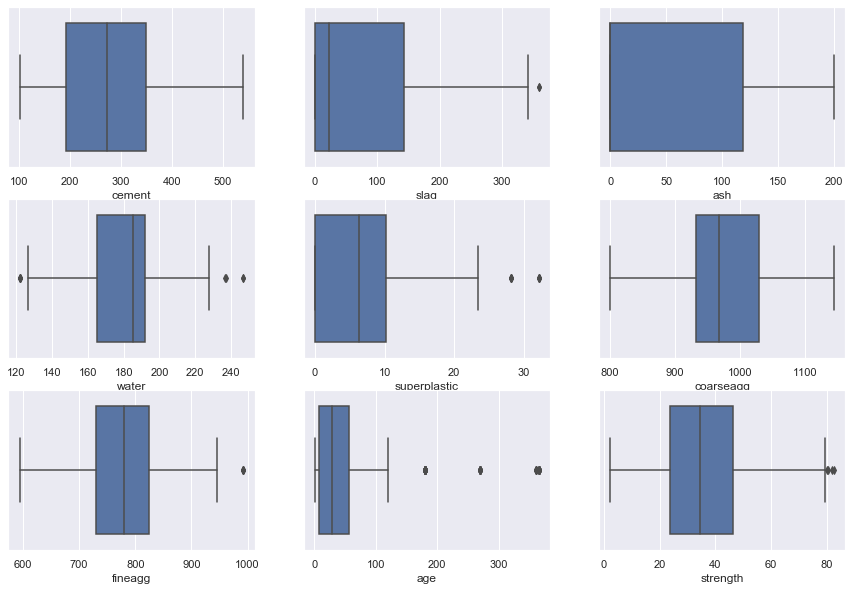

```python
plt.figure(figsize=(15,10))
pos = 1
for i in concData.columns:
    plt.subplot(3, 3, pos)
    sns.boxplot(concData[i])
    pos += 1
```

INSIGHT: There are outliers, rather than handling those separately here - we will apply RobustScaler later in the data handling before application of ML estimator/model

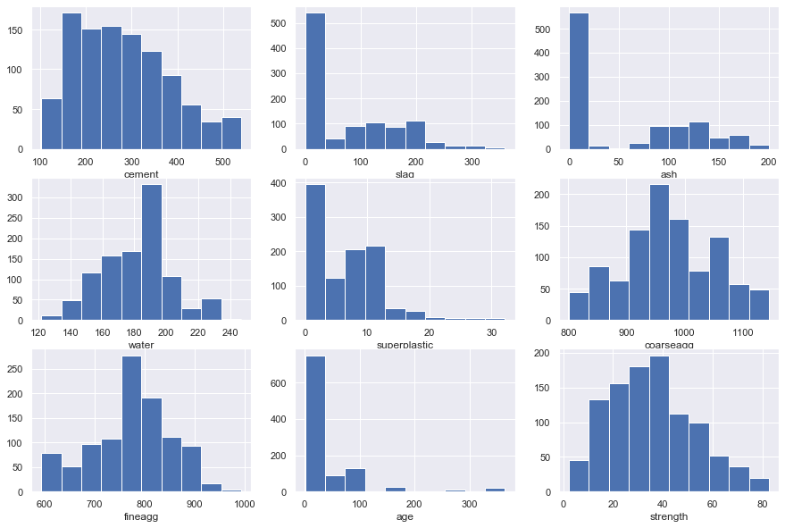

```python
plt.figure(figsize=(15,10))
posHist = 1
for i in concData.columns:
    plt.subplot(3, 3, posHist)
    plt.hist(concData[i])
    plt.xlabel(i)
    posHist += 1
```

### 2. Bi-variate analysis between the predictor variables and between the predictor variables and target column. Comment on your findings in terms of their relationship and degree of relation if any. Visualize the analysis using boxplots and pair plots, histograms or density curves. (10 marks)

```python
concData.corr()
```

|  | cement | slag | ash | water | superplastic | coarseagg | fineagg | age | strength |
| --- | --- | --- | --- | --- | --- | --- | --- | --- | --- |
| cement | 1.000000 | -0.275216 | -0.397467 | -0.081587 | 0.092386 | -0.109349 | -0.222718 | 0.081946 | 0.497832 |
| slag | -0.275216 | 1.000000 | -0.323580 | 0.107252 | 0.043270 | -0.283999 | -0.281603 | -0.044246 | 0.134829 |
| ash | -0.397467 | -0.323580 | 1.000000 | -0.256984 | 0.377503 | -0.009961 | 0.079108 | -0.154371 | -0.105755 |
| water | -0.081587 | 0.107252 | -0.256984 | 1.000000 | -0.657533 | -0.182294 | -0.450661 | 0.277618 | -0.289633 |
| superplastic | 0.092386 | 0.043270 | 0.377503 | -0.657533 | 1.000000 | -0.265999 | 0.222691 | -0.192700 | 0.366079 |
| coarseagg | -0.109349 | -0.283999 | -0.009961 | -0.182294 | -0.265999 | 1.000000 | -0.178481 | -0.003016 | -0.164935 |
| fineagg | -0.222718 | -0.281603 | 0.079108 | -0.450661 | 0.222691 | -0.178481 | 1.000000 | -0.156095 | -0.167241 |
| age | 0.081946 | -0.044246 | -0.154371 | 0.277618 | -0.192700 | -0.003016 | -0.156095 | 1.000000 | 0.328873 |
| strength | 0.497832 | 0.134829 | -0.105755 | -0.289633 | 0.366079 | -0.164935 | -0.167241 | 0.328873 | 1.000000 |

```python
#Check for multi-collinearity between features
# Lets check for highly correlated variables
cor= concData.corr()
cor.loc[:,:] = np.tril(cor,k=-1)
cor=cor.stack()
cor[(cor > 0.8) | (cor< -0.8)]
```

```
Series([], dtype: float64)
```

INSIGHT: Empty series - implies we will not need to worry about multicollinearity between feature variables

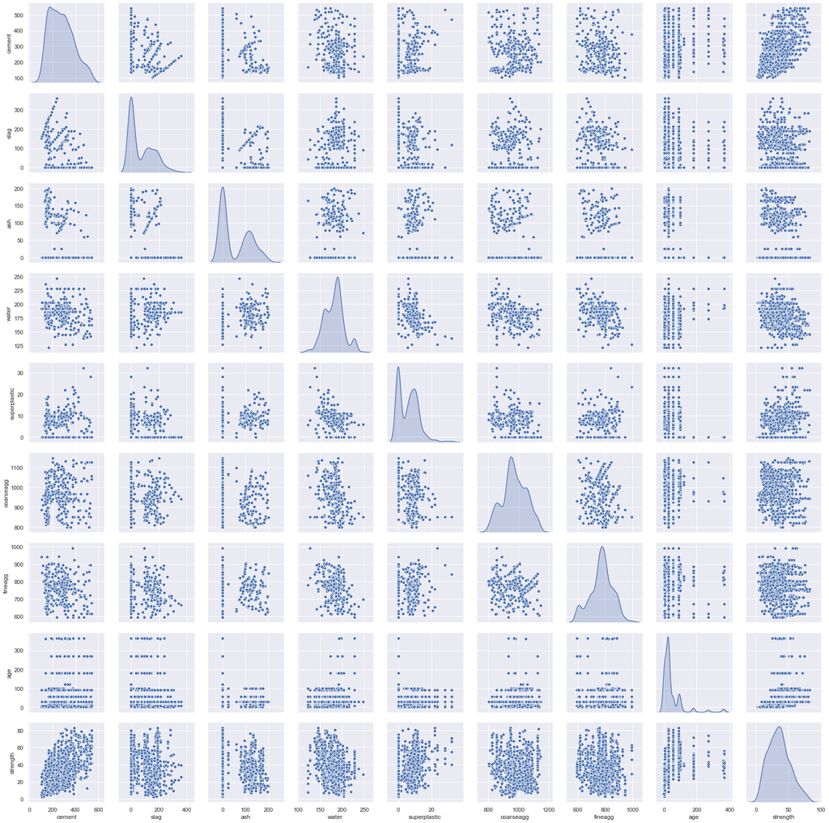

```python
sns.pairplot(concData, palette="husl", diag_kind='kde')
```

### 3. Feature Engineering techniques (10 marks)

```python
#Let do Train-validation-Test split - before refinement -
# Goal will be exploring the opportunities of Features Engineering, to see extra performance improvement which is
#obtainable while keeping two versions of the dataset - while paying attention to prevent using test data to validate

# independant variables
X = concData.drop(['strength'], axis=1)

# the dependent variable
y = concData[['strength']]

# Split X and y into training and test set in 70:30 ratio
X_train, X_test, y_train, y_test = train_test_split(X, y, test_size = 0.30, random_state=42)
```

```python
# Build Lin Reg  to use in feature selection
linR = LinearRegression()
```

```python
# Building feature selection process using - SequentialFeatureSelector, to determine feature relevances
sfs1 = sfs(linR, k_features=5, forward=True, scoring='r2', cv=5)
```

```python
# Perform SFFS
sfs1 = sfs1.fit(X_train.values, y_train.values)
```

```python
sfs1.get_metric_dict()
```

```
{1: {'feature_idx': (0,),
  'cv_scores': array([0.27200432, 0.20423602, 0.26674051, 0.28279478, 0.20872275]),
  'avg_score': 0.2468996748160611,
  'feature_names': ('0',),
  'ci_bound': 0.04297573703108682,
  'std_dev': 0.033436583437221036,
  'std_err': 0.01671829171861052},
 2: {'feature_idx': (0, 4),
  'cv_scores': array([0.34839612, 0.3127373 , 0.35115318, 0.43238798, 0.27529804]),
  'avg_score': 0.343994523813572,
  'feature_names': ('0', '4'),
  'ci_bound': 0.06698386856513995,
  'std_dev': 0.05211572540585022,
  'std_err': 0.026057862702925108},
 3: {'feature_idx': (0, 4, 7),
  'cv_scores': array([0.46137675, 0.49245001, 0.46253841, 0.57292751, 0.38894046]),
  'avg_score': 0.4756466280278241,
  'feature_names': ('0', '4', '7'),
  'ci_bound': 0.07634095142733309,
  'std_dev': 0.059395853763495286,
  'std_err': 0.02969792688174764},
 4: {'feature_idx': (0, 1, 4, 7),
  'cv_scores': array([0.56391505, 0.53891316, 0.48791882, 0.64140146, 0.48180446]),
  'avg_score': 0.5427905890529988,
  'feature_names': ('0', '1', '4', '7'),
  'ci_bound': 0.07475842256100397,
  'std_dev': 0.05816459254178433,
  'std_err': 0.029082296270892163},
 5: {'feature_idx': (0, 1, 3, 4, 7),
  'cv_scores': array([0.55026416, 0.59330194, 0.52651949, 0.69757743, 0.51665175]),
  'avg_score': 0.5768629535325228,
  'feature_names': ('0', '1', '3', '4', '7'),
  'ci_bound': 0.08469194128023753,
  'std_dev': 0.06589320757962748,
  'std_err': 0.03294660378981374}}
```

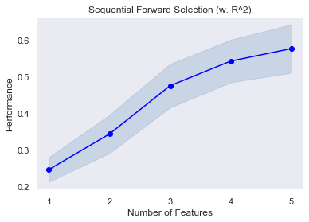

```python
plt.figure(figsize=(15,10))
fig = plot_sfs(sfs1.get_metric_dict())

plt.title('Sequential Forward Selection (w. R^2)')
plt.grid()
plt.show()
```

```python
# Which features have high predictive relevance
columnList = list(X_train.columns)
feat_cols = list(sfs1.k_feature_idx_)
subsetColumnList = [columnList[i] for i in feat_cols]
print(subsetColumnList)
```

```
['cement', 'slag', 'water', 'superplastic', 'age']
```

```python
#For comparison, we check performance difference on selected features and entire features set to see what
#insights we can draw
ml_model = 'Linear Regression'
features_used = 'selected'
linR = LinearRegression()
linR.fit(X_train[subsetColumnList], y_train)
```

```
LinearRegression(copy_X=True, fit_intercept=True, n_jobs=None, normalize=False)
```

```python
y_train_pred = linR.predict(X_train[subsetColumnList])
train_score = linR.score(X_train[subsetColumnList], y_train)
print('Training accuracy on selected features: %.3f' % train_score)
```

```
Training accuracy on selected features: 0.596
```

```python
y_test_pred = linR.predict(X_test[subsetColumnList])
test_score = linR.score(X_test[subsetColumnList], y_test)
print('Testing accuracy on selected features: %.3f' % test_score)
```

```
Testing accuracy on selected features: 0.552
```

```python
featuresPerfDF = pd.DataFrame({'Model' : [ml_model], 'Features' : [features_used], 'Training R2 Score' : [train_score],
                      'Test R2 Score' : [test_score]})
featuresPerfDF
```

|  | Model | Features | Training R2 Score | Test R2 Score |
| --- | --- | --- | --- | --- |
| 0 | Linear Regression | selected | 0.596252 | 0.552486 |

```python
#Performance on Full feature set

ml_model = 'Linear Regression'
features_used = 'All'

linR = LinearRegression()
linR.fit(X_train, y_train)
```

```
LinearRegression(copy_X=True, fit_intercept=True, n_jobs=None, normalize=False)
```

```python
y_train_pred = linR.predict(X_train)
train_score = linR.score(X_train, y_train)
print('Training accuracy on selected features: %.3f' % train_score)
```

```
Training accuracy on selected features: 0.627
```

```python
y_test_pred = linR.predict(X_test)
test_score = linR.score(X_test, y_test)
print('Testing accuracy on selected features: %.3f' % test_score)
```

```
Testing accuracy on selected features: 0.585
```

```python
featuresPerfDF.loc[1] = [ml_model, features_used, train_score, test_score]
featuresPerfDF
```

|  | Model | Features | Training R2 Score | Test R2 Score |
| --- | --- | --- | --- | --- |
| 0 | Linear Regression | selected | 0.596252 | 0.552486 |
| 1 | Linear Regression | All | 0.627147 | 0.584510 |

INSIGHT: We obtained higher R2 Score when we use all the features to build our model, while using selected features has computational performance advantage - its influence was lacking in predictive power in reducing prediction errors

```python
#We desire a scaler that will handle presence of outliers while standardizing the dataset for the estimator
#- from documentation, RobustScaler does that best
rb_scaler = RobustScaler(quantile_range=(25, 75))
```

```python
#Feature Engineering using Polynomial Features - So see if any improvement on Linear Regression - this will be used
# for comparison later
poly = PolynomialFeatures(degree=2, interaction_only=True)
X_train2 = poly.fit_transform(X_train)
X_test2 = poly.fit_transform(X_test)
X_train2.shape, X_test2.shape, y_train.shape, y_test.shape
```

```
((721, 37), (309, 37), (721, 1), (309, 1))
```

## Task 2 - Creating the model and tuning it

### 1. Algorithms that you think will be suitable for this project (at least 3 algorithms). Use Kfold Cross Validation to evaluate model performance. Use appropriate metrics and make a DataFrame to compare models w.r.t their metrics. (15 marks)

```python
num_folds = 10
seed = 42
```

```python
def model_regression_metrics(true_data, pred_data):
    mae = mean_absolute_error(true_data, pred_data)
    mse = mean_squared_error(true_data, pred_data)
    rmse = math.sqrt(mse)
    r2score = r2_score(true_data, pred_data)
    return mae, mse, rmse, r2score
```

```python
def model_regression_plotter(true_data, pred_data):
    # Let's visualize the model against the test data
    plt.figure(figsize=(20,10))
    fig, ax = plt.subplots()
    ax.scatter(true_data, pred_data, edgecolors=(0, 0, 0))
    ax.plot([true_data.min(), true_data.max()], [true_data.min(), true_data.max()], 'k--', lw=4)
    ax.set_xlabel('Actual')
    ax.set_ylabel('Predicted')
    ax.set_title("Actual Concrete Strength vs Predicted")
    plt.show()
```

```python
#making pipeline object for all the estimators that will be used
#1. LinearRegression()
#2. LinearRegression() with Polynomial Features
#3. LinearRegression() - comparison on Lasso and Ridge Regression
#4. DecisionTree Regressor - max_depth=none
#5. DecisionTree Regressor - prune, max_depth=5
#6. RandomForest Regressor
#7. SupportVector Regressor
#8. GradientBoost Regressor
```

```python
#Initializing the KFold for Cross validation to evaluate model performance
kfold = KFold(n_splits=num_folds, random_state=seed)
```

```python
ml_model = 'Linear Regression'
indexer = 0

pipe_lr = make_pipeline(rb_scaler, LinearRegression())
results = cross_val_score(pipe_lr, X, y, cv=kfold)

cv_avg = np.mean(abs(results))
cv_std = results.std()
```

```python
pipe_lr.fit(X_train, y_train)
y_pred= pipe_lr.predict(X_test)

#y_pred = cross_val_predict(pipe_lr, X, y, cv=kfold)
mae, mse, rmse, r2score = model_regression_metrics(y_test, y_pred)
```

```python
resultsDF = pd.DataFrame({'Model' : [ml_model], 'MAE' : [mae], 'MSE' : [mse],
                      'RMSE' : [rmse], 'R2 Score' : [r2score], 'CV_Score_Avg': [cv_avg], 'CV_Score_STD': [cv_std]})
resultsDF
```

|  | Model | MAE | MSE | RMSE | R2 Score | CV_Score_Avg | CV_Score_STD |
| --- | --- | --- | --- | --- | --- | --- | --- |
| 0 | Linear Regression | 8.4677 | 110.771452 | 10.524802 | 0.58451 | 0.59191 | 0.073077 |

```python
print("Model Score average and 95 percent confidence interval: %0.5f (+/- %0.5f)" % (results.mean(),  results.std()* 2))
```

```
Model Score average and 95 percent confidence interval: 0.59191 (+/- 0.14615)
```

```python
#Checking if Poly features extraction will improve our results any better
ml_model = 'Linear Regression - PolyFeatures'
indexer += 1

pipe_lr_poly = make_pipeline(rb_scaler, linear_model.LinearRegression())
results = cross_val_score(pipe_lr_poly, X, y, cv=kfold)

cv_avg = np.mean(abs(results))
cv_std = results.std()

pipe_lr_poly.fit(X_train2, y_train)

y_pred = pipe_lr_poly.predict(X_test2)
```

```python
mae, mse, rmse, r2score = model_regression_metrics(y_test, y_pred)

resultsDF.loc[indexer] = [ml_model, mae, mse, rmse, r2score, cv_avg, cv_std]
resultsDF
```

|  | Model | MAE | MSE | RMSE | R2 Score | CV_Score_Avg | CV_Score_STD |
| --- | --- | --- | --- | --- | --- | --- | --- |
| 0 | Linear Regression | 8.467700 | 110.771452 | 10.524802 | 0.584510 | 0.59191 | 0.073077 |
| 1 | Linear Regression - PolyFeatures | 7.359657 | 86.698913 | 9.311225 | 0.674803 | 0.59191 | 0.073077 |

```python
print("Model Score average and 95 percent confidence interval: %0.5f (+/- %0.5f)" % (results.mean(),  results.std()* 2))
```

```
Model Score average and 95 percent confidence interval: 0.59191 (+/- 0.14615)
```

INSIGHT: Polynomial Features (with only interaction terms) have improved the Out of sample R^2, MSE and other metrics. However at the cost of increaing the number of variables significantly from 8 to 37.

With the general improvement in the R2 Score, however R2 Score generally improves with increase in the number of Features - we can thus not effectively conclude the model is better than the linear regression model

```python
#Using DecisionTreeRegressor
# create a regressor object

ml_model = 'Decision Tree Regressor'
indexer += 1

pipe_dt_rgr = make_pipeline(rb_scaler, DecisionTreeRegressor(random_state = seed))
results = cross_val_score(pipe_dt_rgr, X, y, cv=kfold)

cv_avg = np.mean(abs(results))
cv_std = results.std()
```

```python
pipe_dt_rgr.fit(X_train, y_train)

y_pred= pipe_dt_rgr.predict(X_test)
mae, mse, rmse, r2score = model_regression_metrics(y_test, y_pred)
```

```python
resultsDF.loc[indexer] = [ml_model, mae, mse, rmse, r2score, cv_avg, cv_std]
resultsDF
```

|  | Model | MAE | MSE | RMSE | R2 Score | CV_Score_Avg | CV_Score_STD |
| --- | --- | --- | --- | --- | --- | --- | --- |
| 0 | Linear Regression | 8.467700 | 110.771452 | 10.524802 | 0.584510 | 0.591910 | 0.073077 |
| 1 | Linear Regression - PolyFeatures | 7.359657 | 86.698913 | 9.311225 | 0.674803 | 0.591910 | 0.073077 |
| 2 | Decision Tree Regressor | 3.858414 | 32.902059 | 5.736032 | 0.876588 | 0.867546 | 0.049472 |

```python
print("Model Score average and 95 percent confidence interval: %0.5f (+/- %0.5f)" % (results.mean(),  results.std()* 2))
```

```
Model Score average and 95 percent confidence interval: 0.86755 (+/- 0.09894)
```

INSIGHT: Decision Tree Regression with no restriction on max_depth, gave higher and better, coefficient of determination R^2 , Model score of the prediction than both forms of Linear Regression.

```python
#Checking if improvement is possible with Decision Tree Regressor, when Max_depth is limited to 5

ml_model = 'Decision TreeR(pruned,max_depth=5)'
indexer += 1

pipe_dt_rgr_pruned = make_pipeline(rb_scaler, DecisionTreeRegressor(max_depth=5, random_state = seed))
results = cross_val_score(pipe_dt_rgr_pruned, X, y, cv=kfold)

cv_avg = np.mean(abs(results))
cv_std = results.std()
```

```python
pipe_dt_rgr_pruned.fit(X_train, y_train)

y_pred= pipe_dt_rgr_pruned.predict(X_test)
mae, mse, rmse, r2score = model_regression_metrics(y_test, y_pred)
```

```python
resultsDF.loc[indexer] = [ml_model, mae, mse, rmse, r2score, cv_avg, cv_std]
resultsDF
```

|  | Model | MAE | MSE | RMSE | R2 Score | CV_Score_Avg | CV_Score_STD |
| --- | --- | --- | --- | --- | --- | --- | --- |
| 0 | Linear Regression | 8.467700 | 110.771452 | 10.524802 | 0.584510 | 0.591910 | 0.073077 |
| 1 | Linear Regression - PolyFeatures | 7.359657 | 86.698913 | 9.311225 | 0.674803 | 0.591910 | 0.073077 |
| 2 | Decision Tree Regressor | 3.858414 | 32.902059 | 5.736032 | 0.876588 | 0.867546 | 0.049472 |
| 3 | Decision TreeR(pruned,max_depth=5) | 6.517208 | 73.208112 | 8.556174 | 0.725406 | 0.736434 | 0.039134 |

```python
print("Model average Score and 95 percent confidence interval: %0.5f (+/- %0.5f)" % (results.mean(),  results.std()* 2))
```

```
Model average Score and 95 percent confidence interval: 0.73643 (+/- 0.07827)
```

INSIGHT: Decision Tree Regressor with Max_depth 5 performed worse than unpruned Decision Tree Regressor, opportunity for hyperparamter tuning exist here to get best parameters of the model.

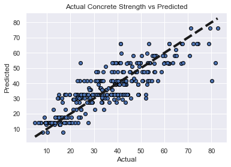

```python
model_regression_plotter(y_test, y_pred)
```

```python
#importances = pipe_dt_rgr.feature_importances_
#print("Important Features: " importances)
```

```python
#Implementing RandomForest Regressor

ml_model = 'RandomForest Regressor'
indexer += 1

pipe_rf_rgr = make_pipeline(rb_scaler, RandomForestRegressor(random_state=seed))
results = cross_val_score(pipe_rf_rgr, X, y, cv=kfold)

cv_avg = np.mean(abs(results))
cv_std = results.std()
```

```python
pipe_rf_rgr.fit(X_train, y_train)

y_pred= pipe_rf_rgr.predict(X_test)
mae, mse, rmse, r2score = model_regression_metrics(y_test, y_pred)
```

```python
resultsDF.loc[indexer] = [ml_model, mae, mse, rmse, r2score, cv_avg, cv_std]
resultsDF
```

|  | Model | MAE | MSE | RMSE | R2 Score | CV_Score_Avg | CV_Score_STD |
| --- | --- | --- | --- | --- | --- | --- | --- |
| 0 | Linear Regression | 8.467700 | 110.771452 | 10.524802 | 0.584510 | 0.591910 | 0.073077 |
| 1 | Linear Regression - PolyFeatures | 7.359657 | 86.698913 | 9.311225 | 0.674803 | 0.591910 | 0.073077 |
| 2 | Decision Tree Regressor | 3.858414 | 32.902059 | 5.736032 | 0.876588 | 0.867546 | 0.049472 |
| 3 | Decision TreeR(pruned,max_depth=5) | 6.517208 | 73.208112 | 8.556174 | 0.725406 | 0.736434 | 0.039134 |
| 4 | RandomForest Regressor | 3.968993 | 32.770213 | 5.724527 | 0.877083 | 0.908203 | 0.022054 |

```python
print("Model average Score and 95 percent confidence interval: %0.5f (+/- %0.5f)" % (results.mean(),  results.std()* 2))
```

```
Model average Score and 95 percent confidence interval: 0.90820 (+/- 0.04411)
```

INSIGHT: RandomForest Regressor has given best the best prediction, followed by unpruned Decision Tree - we will examine if this performance will be exceeded by SVR and GBR

```python
#Implementing SupportVector Regressor

ml_model = 'SupportVector Regressor'
indexer += 1

pipe_svr = make_pipeline(rb_scaler, SVR(C=1.0, epsilon=0.2))
results = cross_val_score(pipe_svr, X, y, cv=kfold)

cv_avg = np.mean(abs(results))
cv_std = results.std()
```

```python
pipe_svr.fit(X_train, y_train)

y_pred= pipe_svr.predict(X_test)
mae, mse, rmse, r2score = model_regression_metrics(y_test, y_pred)
```

```python
resultsDF.loc[indexer] = [ml_model, mae, mse, rmse, r2score, cv_avg, cv_std]
resultsDF
```

|  | Model | MAE | MSE | RMSE | R2 Score | CV_Score_Avg | CV_Score_STD |
| --- | --- | --- | --- | --- | --- | --- | --- |
| 0 | Linear Regression | 8.467700 | 110.771452 | 10.524802 | 0.584510 | 0.591910 | 0.073077 |
| 1 | Linear Regression - PolyFeatures | 7.359657 | 86.698913 | 9.311225 | 0.674803 | 0.591910 | 0.073077 |
| 2 | Decision Tree Regressor | 3.858414 | 32.902059 | 5.736032 | 0.876588 | 0.867546 | 0.049472 |
| 3 | Decision TreeR(pruned,max_depth=5) | 6.517208 | 73.208112 | 8.556174 | 0.725406 | 0.736434 | 0.039134 |
| 4 | RandomForest Regressor | 3.968993 | 32.770213 | 5.724527 | 0.877083 | 0.908203 | 0.022054 |
| 5 | SupportVector Regressor | 6.485591 | 76.544514 | 8.748972 | 0.712891 | 0.721739 | 0.038332 |

```python
print("Model average Score and 95 percent confidence interval: %0.5f (+/- %0.5f)" % (results.mean(),  results.std()* 2))
```

```
Model average Score and 95 percent confidence interval: 0.72174 (+/- 0.07666)
```

```python
#Implementing GradientBoost Regressor

ml_model = 'GradientBoost Regressor'
indexer += 1

pipe_gdr = make_pipeline(rb_scaler, GradientBoostingRegressor(random_state=seed))
results = cross_val_score(pipe_gdr, X, y, cv=kfold)

cv_avg = np.mean(abs(results))
cv_std = results.std()
```

```python
pipe_gdr.fit(X_train, y_train)

y_pred= pipe_gdr.predict(X_test)
mae, mse, rmse, r2score = model_regression_metrics(y_test, y_pred)
```

```python
resultsDF.loc[indexer] = [ml_model, mae, mse, rmse, r2score, cv_avg, cv_std]
resultsDF
```

|  | Model | MAE | MSE | RMSE | R2 Score | CV_Score_Avg | CV_Score_STD |
| --- | --- | --- | --- | --- | --- | --- | --- |
| 0 | Linear Regression | 8.467700 | 110.771452 | 10.524802 | 0.584510 | 0.591910 | 0.073077 |
| 1 | Linear Regression - PolyFeatures | 7.359657 | 86.698913 | 9.311225 | 0.674803 | 0.591910 | 0.073077 |
| 2 | Decision Tree Regressor | 3.858414 | 32.902059 | 5.736032 | 0.876588 | 0.867546 | 0.049472 |
| 3 | Decision TreeR(pruned,max_depth=5) | 6.517208 | 73.208112 | 8.556174 | 0.725406 | 0.736434 | 0.039134 |
| 4 | RandomForest Regressor | 3.968993 | 32.770213 | 5.724527 | 0.877083 | 0.908203 | 0.022054 |
| 5 | SupportVector Regressor | 6.485591 | 76.544514 | 8.748972 | 0.712891 | 0.721739 | 0.038332 |
| 6 | GradientBoost Regressor | 4.002121 | 32.977878 | 5.742637 | 0.876304 | 0.905741 | 0.020147 |

```python
print("Model average Score and 95 percent confidence interval: %0.5f (+/- %0.5f)" % (results.mean(),  results.std()* 2))
```

```
Model average Score and 95 percent confidence interval: 0.90574 (+/- 0.04029)
```

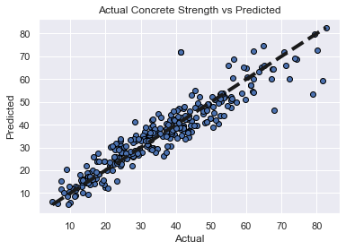

```python
model_regression_plotter(y_test, y_pred)
```

------ Iteration 2 on Linear Regression ---------------

```python
#Can Lasso or Ridge Regression be used to improve the results from the best LinearRegression Model derived
#from Polynomial Features?

ml_model = 'Lasso Regression - Poly'
indexer += 1

lasso = Lasso(alpha=0.01)

pipe_lr_poly_lasso = make_pipeline(rb_scaler, Lasso(alpha=0.01))
results = cross_val_score(pipe_lr_poly_lasso, X_train2, y_train, cv=kfold)

cv_avg = np.mean(abs(results))
cv_std = results.std()
```

```python
pipe_lr_poly_lasso.fit(X_train2, y_train)

y_pred = pipe_lr_poly_lasso.predict(X_test2)
```

```python
mae, mse, rmse, r2score = model_regression_metrics(y_test, y_pred)
```

```python
resultsDF.loc[indexer] = [ml_model, mae, mse, rmse, r2score, cv_avg, cv_std]
resultsDF
```

|  | Model | MAE | MSE | RMSE | R2 Score | CV_Score_Avg | CV_Score_STD |
| --- | --- | --- | --- | --- | --- | --- | --- |
| 0 | Linear Regression | 8.467700 | 110.771452 | 10.524802 | 0.584510 | 0.591910 | 0.073077 |
| 1 | Linear Regression - PolyFeatures | 7.359657 | 86.698913 | 9.311225 | 0.674803 | 0.591910 | 0.073077 |
| 2 | Decision Tree Regressor | 3.858414 | 32.902059 | 5.736032 | 0.876588 | 0.867546 | 0.049472 |
| 3 | Decision TreeR(pruned,max_depth=5) | 6.517208 | 73.208112 | 8.556174 | 0.725406 | 0.736434 | 0.039134 |
| 4 | RandomForest Regressor | 3.968993 | 32.770213 | 5.724527 | 0.877083 | 0.908203 | 0.022054 |
| 5 | SupportVector Regressor | 6.485591 | 76.544514 | 8.748972 | 0.712891 | 0.721739 | 0.038332 |
| 6 | GradientBoost Regressor | 4.002121 | 32.977878 | 5.742637 | 0.876304 | 0.905741 | 0.020147 |
| 7 | Lasso Regression - Poly | 7.228020 | 85.286543 | 9.235071 | 0.680101 | 0.725791 | 0.077872 |

```python
print("Model average Score and 95 percent confidence interval: %0.5f (+/- %0.5f)" % (results.mean(),  results.std()* 2))
```

```
Model average Score and 95 percent confidence interval: 0.72579 (+/- 0.15574)
```

```python
ml_model = 'Ridge Regression - Poly'
indexer += 1

pipe_lr_poly_ridge = make_pipeline(rb_scaler, Ridge(alpha=.3))
results = cross_val_score(pipe_lr_poly_ridge, X_train2, y_train, cv=kfold)

cv_avg = np.mean(abs(results))
cv_std = results.std()
```

```python
pipe_lr_poly_ridge.fit(X_train2, y_train)

y_pred = pipe_lr_poly_ridge.predict(X_test2)
```

```python
mae, mse, rmse, r2score = model_regression_metrics(y_test, y_pred)
```

```python
resultsDF.loc[indexer] = [ml_model, mae, mse, rmse, r2score, cv_avg, cv_std]
resultsDF
```

|  | Model | MAE | MSE | RMSE | R2 Score | CV_Score_Avg | CV_Score_STD |
| --- | --- | --- | --- | --- | --- | --- | --- |
| 0 | Linear Regression | 8.467700 | 110.771452 | 10.524802 | 0.584510 | 0.591910 | 0.073077 |
| 1 | Linear Regression - PolyFeatures | 7.359657 | 86.698913 | 9.311225 | 0.674803 | 0.591910 | 0.073077 |
| 2 | Decision Tree Regressor | 3.858414 | 32.902059 | 5.736032 | 0.876588 | 0.867546 | 0.049472 |
| 3 | Decision TreeR(pruned,max_depth=5) | 6.517208 | 73.208112 | 8.556174 | 0.725406 | 0.736434 | 0.039134 |
| 4 | RandomForest Regressor | 3.968993 | 32.770213 | 5.724527 | 0.877083 | 0.908203 | 0.022054 |
| 5 | SupportVector Regressor | 6.485591 | 76.544514 | 8.748972 | 0.712891 | 0.721739 | 0.038332 |
| 6 | GradientBoost Regressor | 4.002121 | 32.977878 | 5.742637 | 0.876304 | 0.905741 | 0.020147 |
| 7 | Lasso Regression - Poly | 7.228020 | 85.286543 | 9.235071 | 0.680101 | 0.725791 | 0.077872 |
| 8 | Ridge Regression - Poly | 7.189948 | 84.075171 | 9.169251 | 0.684645 | 0.728430 | 0.074272 |

```python
#Sorting Algorithms based on performance on Cross validation scores,
#which is highly correlated with R2Score on Test data
resultsDF.sort_values(by='CV_Score_Avg', ascending=False).reset_index(drop=True)
```

|  | Model | MAE | MSE | RMSE | R2 Score | CV_Score_Avg | CV_Score_STD |
| --- | --- | --- | --- | --- | --- | --- | --- |
| 0 | RandomForest Regressor | 3.968993 | 32.770213 | 5.724527 | 0.877083 | 0.908203 | 0.022054 |
| 1 | GradientBoost Regressor | 4.002121 | 32.977878 | 5.742637 | 0.876304 | 0.905741 | 0.020147 |
| 2 | Decision Tree Regressor | 3.858414 | 32.902059 | 5.736032 | 0.876588 | 0.867546 | 0.049472 |
| 3 | Decision TreeR(pruned,max_depth=5) | 6.517208 | 73.208112 | 8.556174 | 0.725406 | 0.736434 | 0.039134 |
| 4 | Ridge Regression - Poly | 7.189948 | 84.075171 | 9.169251 | 0.684645 | 0.728430 | 0.074272 |
| 5 | Lasso Regression - Poly | 7.228020 | 85.286543 | 9.235071 | 0.680101 | 0.725791 | 0.077872 |
| 6 | SupportVector Regressor | 6.485591 | 76.544514 | 8.748972 | 0.712891 | 0.721739 | 0.038332 |
| 7 | Linear Regression | 8.467700 | 110.771452 | 10.524802 | 0.584510 | 0.591910 | 0.073077 |
| 8 | Linear Regression - PolyFeatures | 7.359657 | 86.698913 | 9.311225 | 0.674803 | 0.591910 | 0.073077 |

### 2. Techniques employed to squeeze that extra performance out of the model without making it over fit. Use Grid Search or Random Search on any of the two models used above. Make a DataFrame to compare models after hyperparameter tuning and their metrics as above. (15 marks)

```python
#Validation set will be 75:25 of train set, which contains larger data - this is necessary so we don't
#tune hyperparameters on seen data - information leak, but on unseen data - validation set
X_train, X_val, y_train, y_val = train_test_split(X_train, y_train, test_size=0.25, random_state=1)
X_train.shape, X_test.shape, y_train.shape, y_test.shape, X_val.shape, y_val.shape
```

```
((540, 8), (309, 8), (540, 1), (309, 1), (181, 8), (181, 1))
```

```python
#Using GridSearchCV on best two models above - to examine if extra performance can be obtained
#1. RandomForestRegressor
#2. GradientBoostRegressor
```

```python
def showTunedModelfit(ml_alg, performCV=True, printFeatureImportance=True, cv_folds=num_folds):

    #Fit the best algorithm on the data not seen
    ml_alg.fit(X_val, y_val)

    #Predict training set, test the model:
    dtrain_predictions = ml_alg.predict(X_test)
    mae, mse, rmse, r2score = model_regression_metrics(y_test, dtrain_predictions)


    #Perform cross-validation:
    if performCV:
        cv_score = cross_val_score(ml_alg, X_val, y_val, cv=cv_folds)

    #Print model report:
    print ( "\nModel Report")
    print ("R2 Score : %.4g" %  r2score)
    print ("MSE: %f" % mse)

    if performCV:
        print("CV Score : Mean - %.7g | Std - %.7g | Min - %.7g | Max - %.7g" % (np.mean(cv_score),np.std(cv_score),np.min(cv_score),np.max(cv_score)))

    #Print Feature Importance:
    predictors = X_val.columns
    if printFeatureImportance:
        feat_imp = pd.Series(ml_alg.feature_importances_, predictors).sort_values(ascending=False)
        feat_imp.plot(kind='bar', title='Feature Importances')
        plt.ylabel('Feature Importance Score')

    return mae, mse, rmse, r2score
```

[output not shown]

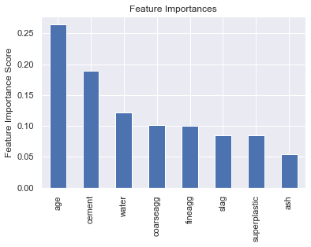

```python
#Due to performance constraints - will limit number and scope of hyper parameters to tune
#RandomForest Regression
#Desired Hyperparamters

#
#"n_estimators":[100,200,300],
# "max_depth": [3, None],
#"max_features": ["auto", "sqrt", "log2"],
#"min_samples_split": [2, 3, 10],
#"min_samples_leaf": [1, 3, 10],
#"bootstrap": [True, False],
#"criterion": ["mse", "mae"]
#

# RandomForest Regressor - Hyperparameters use a full grid over all parameters
rfr_param_grid = {"n_estimators":[100,200],
                  "max_depth": [3, None],
                  "max_features": ["auto", "sqrt"],
                  "bootstrap": [True, False],
                  "criterion": ["mse", "mae"]}


#
#"max_depth": [3, None],
#"max_features": [auto", "sqrt", "log2"],
#"min_samples_split": [2, 3, 10],
# "min_samples_leaf": [1, 3, 10],
# "learning_rate": [0.1, 0.3, 0.5],
# "criterion": ["friedman_mse", "mse", "mae"],
#"loss":["ls", "lad", "huber", "quantile"],
# "n_estimators":[100,200,300]
#


#use grid over paramaters for GradientBoost Regressor
gdr_param_grid = {"max_depth": [3, None],
                  "max_features": ["auto", "sqrt"],
                  "criterion": ["friedman_mse", "mse", "mae"],
                  "loss":["ls", "lad"],
                  "n_estimators":[100,200]}

#Implement grid search
rfr = RandomForestRegressor(random_state=seed)
rfr_gs = GridSearchCV(rfr,rfr_param_grid,cv=num_folds)

rfr_gs.fit(X_train, y_train)
rfr_gs.best_params_
rfr_gs.cv_results_['params']
rfr_gs.cv_results_['mean_test_score']

#Create visual display of the best estimator
mae, mse, rmse, r2score = showTunedModelfit(rfr_gs.best_estimator_)
```

```python
#Insert Result into DataFrame
ml_model = "Grid-Tuned RandomForest Regressor"
turnedResultsDF = pd.DataFrame({'Model' : [ml_model], 'MAE' : [mae], 'MSE' : [mse],
                      'RMSE' : [rmse], 'R2 Score' : [r2score]})
turnedResultsDF
```

|  | Model | MAE | MSE | RMSE | R2 Score |
| --- | --- | --- | --- | --- | --- |
| 0 | Grid-Tuned RandomForest Regressor | 4.839794 | 44.981515 | 6.706826 | 0.83128 |

```python
print(rfr_gs.best_params_)
```

```
{'bootstrap': False, 'criterion': 'mae', 'max_depth': None, 'max_features': 'sqrt', 'n_estimators': 100}
```

[output not shown]

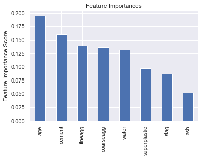

```python
#Checking for improvement in GradientBoost Regressor

ml_model = "Grid-Tuned GradientBoost Regressor"
gdr = GradientBoostingRegressor(random_state=seed)
gdr_gs = GridSearchCV(gdr,gdr_param_grid,cv=num_folds)

gdr_gs.fit(X_train, y_train)
gdr_gs.best_params_
gdr_gs.cv_results_['params']
gdr_gs.cv_results_['mean_test_score']

#Create visual display of the best estimator
mae, mse, rmse, r2score = showTunedModelfit(gdr_gs.best_estimator_)
```

```python
turnedResultsDF.loc[1] = [ml_model, mae, mse, rmse, r2score]
turnedResultsDF
```

[output not shown]

```python
print(gdr_gs.best_params_)
```

```
{'criterion': 'friedman_mse', 'loss': 'lad', 'max_depth': None, 'max_features': 'auto', 'n_estimators': 200}
```

### CONCLUSION -

It can be concluded that the top five most important features or properties affecting the compressive strength of Concrete are age, cement, fineagg, coarseagg and water - three of which were among top features also for linear regression.